# Single cell RNA-seq data analysis

## Introduction

In this section, you will go through the most basic steps for Single cell RNA seq analysis with R packages including:

[Seurat](http://satijalab.org/seurat/Seurat_AlignmentTutorial.html) package from Satija Lab et al [dplyr](https://cran.r-project.org/web/packages/dplyr/) package from Hadley Wickham et.al [Matrix](https://cran.r-project.org/web/packages/Matrix/) package from Douglas Bates et.al [Matrix.utils](https://cran.r-project.org/web/packages/Matrix.utils/) package from Craig Varrichio [ggplot2](https://cran.r-project.org/web/packages/ggplot2/) package from Hadley Wickham et.al [reshape2](https://cran.r-project.org/web/packages/reshape2/) package from Hadley Wickham [pryr](https://cran.r-project.org/web/packages/pryr/) package from Hadley Wickham et.al [RColorBrewer](https://cran.r-project.org/web/packages/RColorBrewer/) package from Erich Neuwirth And local source from genetic department of UMCG

## Public data

Data used in this section is freely available from 10X Genomics, with 2700 single cells that were sequenced on the Illumina NextSeq 500 there is a link to data from website of Seurat

## Setting working directory

```r
#change it to where you put the materials
#setwd("E:/workshop/scRNA/filtered_gene_bc_matrices/")
```

## Loading packages & source

If you don’t have these packages, please install them

```r
#make sure your R have v >= 3.3
#install.packages('Seurat')
#install.packages('dplyr')
#install.packages('Matrix')
#install.packages('Matrix.utils')
#install.packages('ggplot2')
#install.packages('reshape2')
#install.packages('pryr')
#install.packages('RColorBrewer')

library(Seurat)
library(dplyr)
library(Matrix)
library(Matrix.utils)
```

```r
library(ggplot2)
library(reshape2)
```

```r
library(pryr)
```

```r
library(RColorBrewer)
```

```r
source("../get_genes_function.R")
```

## Loading data in Seurat

```r
pbmc.data <- Read10X(data.dir = "./hg19")
```

## QC and selecting cells for further analysis

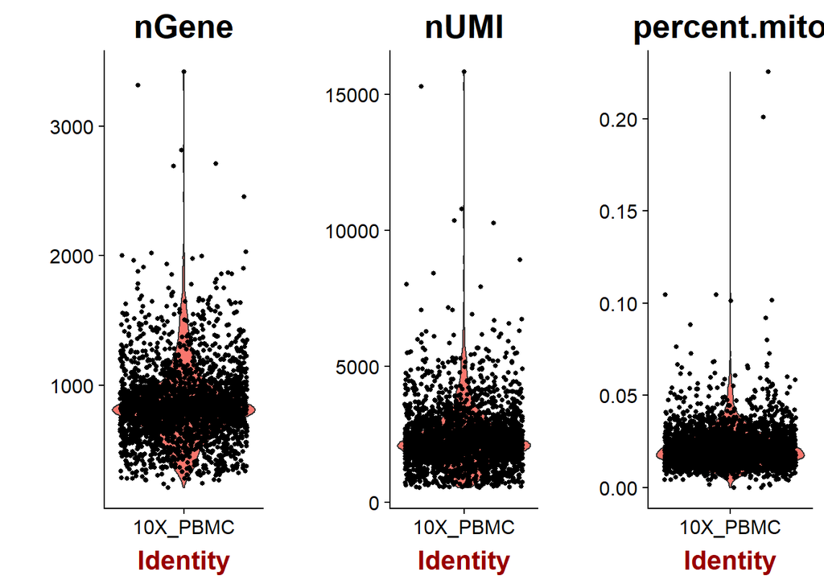

```r
# Initialize the Seurat object with the raw (non-normalized data).  Keep all
# genes expressed in >= 3 cells (~0.1% of the data). Keep all cells with at
# least 200 detected genes

pbmc <- CreateSeuratObject(raw.data = pbmc.data, min.cells = 3, min.genes = 200,
                           project = "10X_PBMC")

# The number of genes and UMIs (nGene and nUMI) are automatically calculated
# for every object by Seurat.  For non-UMI data, nUMI represents the sum of
# the non-normalized values within a cell We calculate the percentage of
# mitochondrial genes here and store it in percent.mito using AddMetaData.
# We use object@raw.data since this represents non-transformed and
# non-log-normalized counts The % of UMI mapping to MT-genes is a common
# scRNA-seq QC metric.
mito.genes <- grep(pattern = "^MT-", x = rownames(x = pbmc@data), value = TRUE)
percent.mito <- Matrix::colSums(pbmc@raw.data[mito.genes, ])/Matrix::colSums(pbmc@raw.data)
# AddMetaData adds columns to object@meta.data, and is a great place to
# stash QC stats
pbmc <- AddMetaData(object = pbmc, metadata = percent.mito, col.name = "percent.mito")


VlnPlot(object = pbmc, features.plot = c("nGene", "nUMI", "percent.mito"), nCol = 3)
```

```r
# We filter out cells that have unique gene counts over 2,500 or less than 200
# and cells with high "percent.mito" (>0.05)
#Note that low.thresholds and high.thresholds are used to define a
# 'gate'.  -Inf and Inf should be used if you don't want a lower or upper
# threshold.
pbmc <- FilterCells(object = pbmc, subset.names = c("nGene", "percent.mito"),
                    low.thresholds = c(200, -Inf), high.thresholds = c(2500, 0.05))
##the numbers on the pictures are correlation coefficients
```

[output not shown]

Question 1: Why it’s important to filter out cells with high unique gene counts?

## Normalizing the data

By default, we employ a global-scaling normalization method “LogNormalize” that normalizes the gene expression measurements for each cell by the total expression, multiplies this by a scale factor (10,000 by default), and log-transforms the result

```r
pbmc <- NormalizeData(object = pbmc, normalization.method = "LogNormalize",
                      scale.factor = 10000)
```

## Detection of variable genes across the single cells

genes with extremly low (0.0125) and high (3) mean expression value were removed genes with low variation (y.cutoff = 0.5) were removed

```r
pbmc <- FindVariableGenes(object = pbmc, mean.function = ExpMean, dispersion.function = LogVMR,
                          x.low.cutoff = 0.0125, x.high.cutoff = 3, y.cutoff = 0.5)
```

[figure not shown]

```r
length(x = pbmc@var.genes)
```

```
## [1] 1838
```

## Scaling the data and removing unwanted sources of variation

regress out unwanted sources (batch effect, cell cycle stage, detected molecules per cell, the percentage mitochondrial gene content et.al)

here we only regress out detected molecules per cell (nUMI) and the percentage mitochondrial gene content evaluated before.

```r
pbmc <- ScaleData(object = pbmc, vars.to.regress = c("nUMI", "percent.mito"))
```

```
##
## Time Elapsed:  52.0471968650818 secs
```

```
## Scaling data matrix
```

Question 2: How to define “unwanted sources” ?

## Perform linear dimensional reduction

```r
pbmc <- RunPCA(object = pbmc, pc.genes = pbmc@var.genes, do.print = TRUE, pcs.print = 1:5,
               genes.print = 5)
```

```
## [1] "PC1"
## [1] "CST3"   "TYROBP" "FCN1"   "LST1"   "AIF1"
## [1] ""
## [1] "PTPRCAP" "IL32"    "LTB"     "CD2"     "CTSW"
## [1] ""
## [1] ""
## [1] "PC2"
## [1] "NKG7" "GZMB" "PRF1" "CST7" "GZMA"
## [1] ""
## [1] "CD79A"    "MS4A1"    "HLA-DQA1" "TCL1A"    "HLA-DQB1"
## [1] ""
## [1] ""
## [1] "PC3"
## [1] "CYBA"     "HLA-DPA1" "HLA-DPB1" "HLA-DRB1" "CD37"
## [1] ""
```

[output cut: 16 more lines]

you can find the first 5 marker genes for the first 5 PCs

PCs exploration. finding correlated gene sets could be useful to explain PCs as reference for deciding PCs included in clustering

draw the first 12 PCs with 500 cells (extreme cells selected for accelarating cauculation)

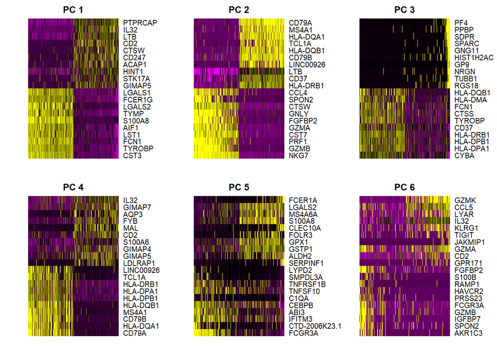

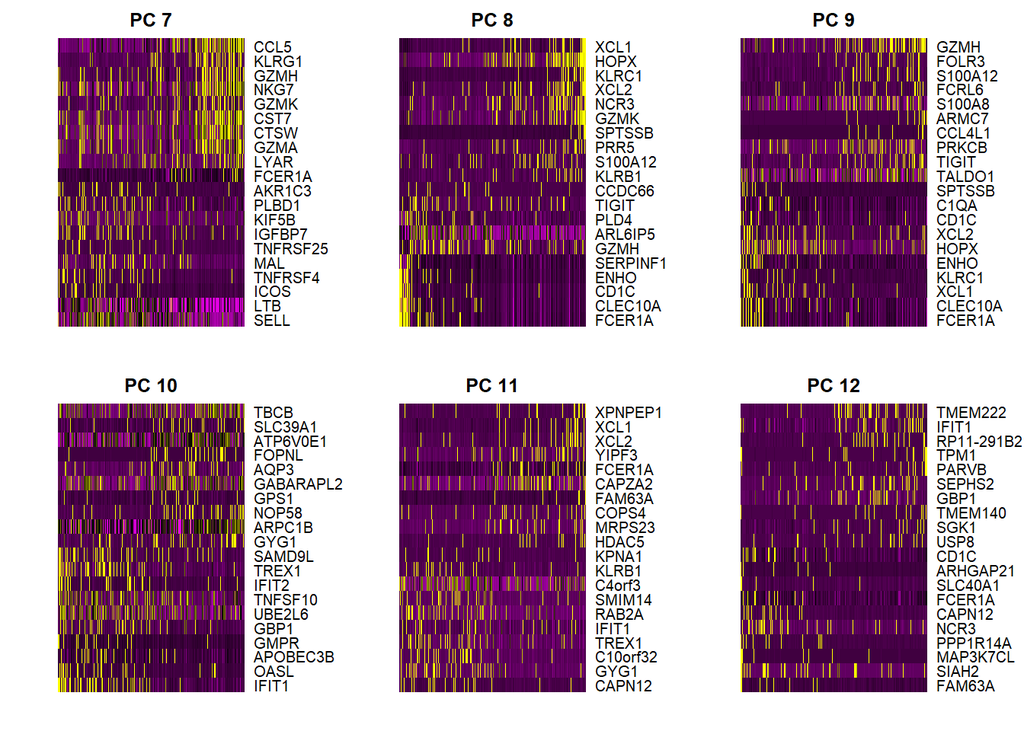

```r
PCHeatmap(object = pbmc, pc.use = 1:12, cells.use = 500, do.balanced = TRUE,
          label.columns = FALSE, use.full = FALSE,num.genes = 20)
```